# Frank Grimes - Sentiment Analysis

S.Mckinnon

July 2016

[figure not shown]

### *Background*

In Season 8, epi 23 of the [Simpsons](https://en.wikipedia.org/wiki/Homer%27s_Enemy) contained one of the most memorable characters, **Frank Grimes**.

[figure not shown]

*“The episode explores the comic possibilities of a realistic character with a strong work ethic hired for a job where he has to work alongside a man like Homer…. Despite Homer’s attempts to befriend him, Grimes is angered and irritated by Homer’s laziness and incompetence despite leading a comfortable life. He eventually declares himself Homer’s enemy.”* - [Wiki](https://en.wikipedia.org/wiki/Homer%27s_Enemy)

Which begs the question, whats the text sentiment of this episode?

[figure not shown]

### *Data Processing*

The first step is to get source the [episode script](http://www.springfieldspringfield.co.uk/view_episode_scripts.php?tv-show=the-simpsons&episode=s08e23) and load it in for processing.

Once loaded some pre-processing of the data is required. For this the [Stringr](https://cran.r-project.org/web/packages/stringr/vignettes/stringr.html) & [dplyr](https://cran.rstudio.com/web/packages/dplyr/vignettes/introduction.html) packages are used.

```r
library(stringr)
library(dplyr)
#remove special chars
simp$V1 <- str_replace_all(simp$V1, "[^[:alnum:]]", " ")
#update the column name
colnames(simp) <- c( "Lines")
```

Next comes the [TM](https://cran.r-project.org/web/packages/tm/vignettes/tm.pdf) and the [SnowballC](https://cran.r-project.org/web/packages/SnowballC/index.html) packages, which is used to clean up the text and make it easier to analyse.

```r
library(tm)
library(SnowballC)
#create a corpus for analysis
simp_cp <- Corpus(VectorSource(simp))
#clean up corpus
simp_cp <- tm_map(simp_cp, tolower)
simp_cp <- tm_map(simp_cp, PlainTextDocument)
simp_cp <- tm_map(simp_cp, removePunctuation)
simp_cp <- tm_map(simp_cp, removeNumbers)
simp_cp <- tm_map(simp_cp, removeWords, stopwords("english"))
# stem the corpus
simp_cp <- tm_map(simp_cp, stemDocument)
#clean out the white spaces
simp_cp <- tm_map(simp_cp, stripWhitespace)
# review the resulting output
head(simp_cp)
```

```
## <<VCorpus>>
## Metadata:  corpus specific: 0, document level (indexed): 0
## Content:  documents: 1
```

This raw data will need to be converted in a [Document Term Matrix](https://en.wikipedia.org/wiki/Document-term_matrix) for a more indepth review.

```r
#make into matrix
simp_dtm <-  DocumentTermMatrix(simp_cp)
#most common terms
head(sort(colSums(as.matrix(simp_dtm)), decreasing=TRUE),20)
```

```
##   homer    like simpson     can    work     don    just     man   groan
##      22      16      16      15      15      14      12      12      11
##   grime    okay   plant    yeah   frank     get     got   laugh    look
##      10      10      10      10       9       9       9       9       9
##    make  chuckl
##       9       8
```

This can be best represented in a [Word Cloud](https://georeferenced.wordpress.com/2013/01/15/rwordcloud/)

[figure not shown]

```r
library(wordcloud)
library(RColorBrewer)

#wordcloud requires a seed to reproduce outcomes
set.seed(142)

wordcloud(simp_cp, scale=c(5,0.5), max.words=100, random.order=FALSE, rot.per=0.35, use.r.layout=FALSE, colors=brewer.pal(8, "Dark2"))
```

But what of the sentiment?

### *Option 1 - Basic Word Matching*

The first option is basic wording match to a positive and negative lexicon, the summary of which desides the sentiment. This approach is detailed [here](http://www.r-bloggers.com/sentiment-analysis-on-donald-trump-using-r-and-tableau/).

```r
#load in the pos & neg lexicons
positives= readLines("positive-words.txt")
negatives = readLines("negative-words.txt")
# write a basic function to calc each rows setiment
sentiment_scores = function(df, positive_words, negative_words){
    df_score <-data.frame(Score=integer())

    for (i in 1:nrow(df)) {
      #make lower
      df_l = tolower(df[i,])
      # split sentence into words with str_split function from stringr package
      word_list = str_split(df_l, " ")
      words = unlist(word_list)
      # get the position of the matched term or NA
      # we just want a TRUE/FALSE
      positive_matches = sum(!is.na(match(words,positives)), na.rm=TRUE)
      negative_matches = sum(!is.na(match(words,negatives)), na.rm=TRUE)
      #get scores
      score = sum(positive_matches) - sum(negative_matches)
      df_score[i,] <- score

    }
    return(df_score)
}
```

Then simply run the function and graph the results, using [ggplot](http://docs.ggplot2.org/current/).

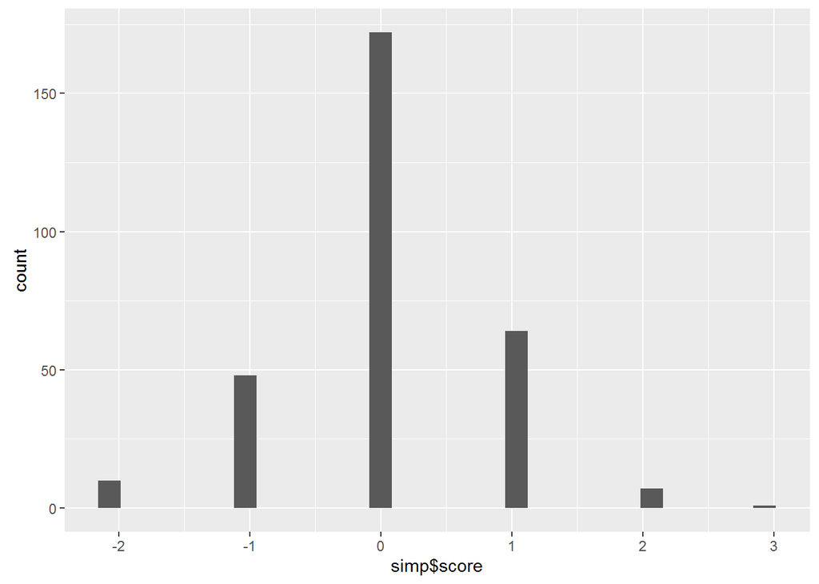

```r
#run the function
score = sentiment_scores(simp, positives, negatives)
#append the score to the data
simp$score=score

#Let's plot a histogram of the sentiment score:
library(ggplot2)
qplot(simp$score, geom="histogram")
```

There are a number of issues with this approach. So next I decided to have a look at a more robust approach.

### *Option 2 - A Setiment package*

With the idea from the [Julia Silge Blog](http://juliasilge.com/blog/Joy-to-the-World/), the [Syuzhet package](https://cran.r-project.org/web/packages/syuzhet/vignettes/syuzhet-vignette.html) which has the goal of *“..quickly extract plot and sentiment data from your own text files..”*

First step, once again is to bring the data in and pre-process it.

```r
library(syuzhet)
#import data, use 2 to get a complete line.
simp <- read.csv2("SIMP_s08_e23.txt",
                  header=FALSE,
                  na.strings=c("-", "[", "]"),
                  blank.lines.skip=TRUE)
#remove special chars, as the full stop is required for the sentence structure function.
simp1 <- gsub("\\[", " ", simp$V1)
simp1 <- gsub("\\]", " ", simp1)
simp1 <- gsub("-", " ", simp1)
simp1 <- gsub("\\(", " ", simp1)
simp1 <- gsub("\n", " ", simp1)

# get sentence structure
simp_sent <- get_sentences(simp1)
```

From this structure, we can get the sentiment stats.

```r
#get sentiment
simp_sentiment <- get_nrc_sentiment(simp_sent)

head(simp_sentiment)
```

```
##   anger anticipation disgust fear joy sadness surprise trust negative
## 1     1            1       1    1   1       1        1     1        1
## 2     0            0       0    0   0       0        0     0        0
## 3     1            0       0    1   0       1        0     1        1
## 4     1            0       0    1   0       1        0     2        1
## 5     0            1       1    0   1       0        0     0        2
## 6     0            1       0    1   1       0        2     0        1
##   positive
## 1        2
## 2        0
## 3        1
## 4        1
## 5        3
## 6        1
```

From here, the data can be transformed for graphing.

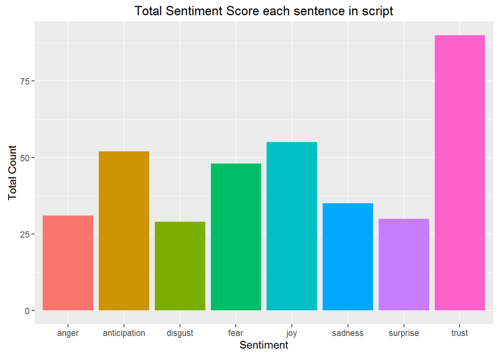

```r
#make a data frame of the totals
sentimentTotals <- data.frame(colSums(simp_sentiment[,c(1:8)]))
#give it a meaningful name
names(sentimentTotals) <- "count"
#create the graph data frame
sentimentTotals <- cbind("sentiment" = rownames(sentimentTotals), sentimentTotals)
rownames(sentimentTotals) <- NULL
#create the bar chart
ggplot(data = sentimentTotals, aes(x = sentiment, y = count)) +
  geom_bar(aes(fill = sentiment), stat = "identity") +
  theme(legend.position = "none") +
  xlab("Sentiment") + ylab("Total Count") + ggtitle("Total Sentiment Score each sentence in script")
```

#### *Conclusion*

*“To prove Homer’s lack of intelligence, he tricks Homer into entering a nuclear power plant design contest intended for children…. At the contest, Grimes is shocked when Homer’s model easily wins..The audience’s applause and cheers for Homer cause Grimes to finally snap and he runs amok through the plant… sarcastically declares that he does not need safety gloves, grabs the high voltage wires and is killed by electrocution. At Grimes’ funeral, Homer falls asleep …causing all the attending mourners to laugh as Grimes’ casket is lowered into the ground.”*

Despite this, both approaches suggest this episode has a neutral to slightly positive sentiment.

[figure not shown]

#### *Notes*

The Key notes of this analysis are:

- The full episode description can be found [here](https://en.wikipedia.org/wiki/Homer%27s_Enemy)
- The idea for this can be found here - [Text Mining R on Vikings](http://www.r-bloggers.com/text-mining-with-r-on-vikings-episode-scripts/)
- The initial sentiment analysis can be found here - [Sentiment Analysis on Trump Tweets](http://www.r-bloggers.com/sentiment-analysis-on-donald-trump-using-r-and-tableau/)
- The introduction for the 2nd sentiment analysis approach can be found here - [Julia Silge Blog](http://juliasilge.com/blog/Joy-to-the-World/)
- The [Syuzhet package](https://cran.r-project.org/web/packages/syuzhet/vignettes/syuzhet-vignette.html) is described in this summary.

**– end of document –**